# Cap 6 - Resumo

Diogo Bolzan - 00580408

2024-01-15

[figure not shown]

[figure not shown]

# Capítulo 6 - Autovetores e Autovalores

## Autovetores e Autovalores

$\text{Um } \textbf{autovetor} \text{ de uma matriz n x n, é um vetor não nulo x tal que }Ax=\lambda x \text{ para algum escalar }\lambda. \lambda \text{ será chamado de }\textbf{autovalor}\text{ para A.}$

$\text{Vamos verificar o que são autovetores geométricamente:}$

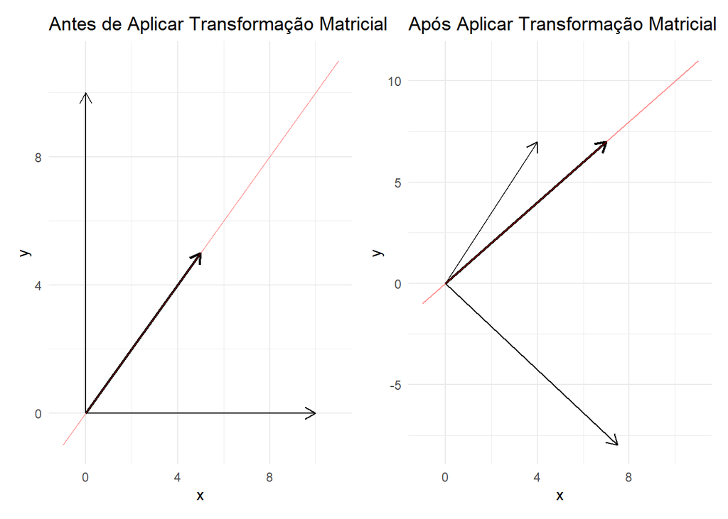

$\text{Geométricamente temos que um autovetor mesmo após aplicar a transformação matricial ele irá continar na mesma direção alterando apenas o comprimento e sentido!}$ $\text{O comprimento e sentido será alterado por um multiplo, esse multiplo é o autovalor!}$

$\text{Em geral os exercícios irão pedir para verificar se é um autovalor ou autovetor}$ $\text{Para autovalor basta usar a seguinte fórmula: }(A-\lambda I)x=0$

$\text{Verifique se }\lambda \text{=7 é um autovalor para A:}$
$$A =
\left(\begin{array}{cc}
1 & 6 \\
5 & 2 \\
\end{array}\right) e, \lambda=7 =>
\left(\begin{array}{cc}
1 & 6 \\
5 & 2 \\
\end{array}\right) - \left(\begin{array}{cc}
7 & 0 \\
0 & 7 \\
\end{array}\right) =
\left(\begin{array}{cc}
-6 & 6 \\
5 & -5 \\
\end{array}\right)$$
$$\text{Escalonando} =
\left(\begin{array}{cc|c}
-6 & 6 & 0\\
5 & -5 & 0\\
\end{array}\right) =
\left(\begin{array}{cc|c}
1 & -1 & 0\\
0 & 0 & 0\\
\end{array}\right)$$
$\text{Temo que as colunas são Linearmente Dependentes pois não há pivo em cada coluna, logo é autovalor!}$

$\text{Para mostrar que é autovetor é simples basta multiplicar A pelo autovetor!}$

$\text{Considerando a matriz A, verifique se o vetor v = (1,1) é autovetor de A:}$
$$A = \left(\begin{array}{cc}
1 & 6 \\
5 & 2 \\
\end{array}\right) , v =
\left(\begin{array}{cc}
1 \\
1 \\
\end{array}\right) =
\left(\begin{array}{cc}
7 \\
7 \\
\end{array}\right) =
\left(\begin{array}{cc}
1 \\
1 \\
\end{array}\right) * 7$$

$\text{É fácil de ver gráficamente que v é um autovetor de A, que mesmo após aplicar a transformação linear,}$ $\text{continua crescendo na mesma direção mas com tamanho diferente (multiplicado pelo autovalor 7), enquanto os demais trocam de direção}$

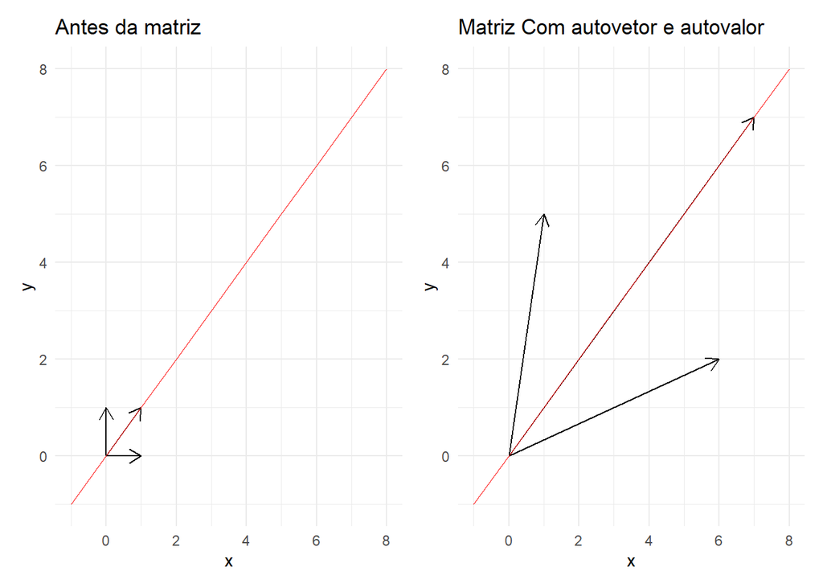

$\text{Como veremos futuramente o 7 não é o único autovalor para essa matriz temos ainda o -4:}$

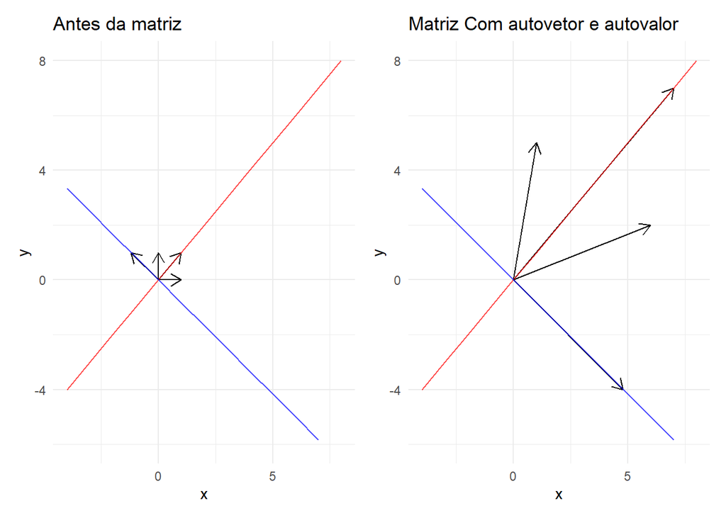

$\text{Verifique se v é autovetor de A:}$
$$A =\left(\begin{array}{ccc}
1 & -1 & 2\\
4 & -3 & 1\\
-1 & 4 & -1 \\
\end{array}\right), v=
\left(\begin{array}{cc|c}
1 \\
1 \\
1 \\
\end{array}\right) =
\left(\begin{array}{ccc}
1*1 & -1*1 & 2*1\\
4*1 & -3*1 & 1*1\\
-1*1 & 4*1 & -1*1 \\
\end{array}\right) =
\left(\begin{array}{ccc}
2 \\
2 \\
2 \\
\end{array}\right) = 2 *
\left(\begin{array}{cc|c}
1 \\
1 \\
1 \\
\end{array}\right) = \lambda = 2$$

$\text{Esse último exemplo foi retirado da lista do professor!}$

$\text{OBS: Em alguns exercício o professor gosta de combinar assuntos, como encontrar o espaço nulo que é o mesmo que fazer Nul(A-Ilambda) e ver quantas colunas são L.I}$ $\text{Se a matriz A for triÂngular (haver valorez iguais a zero em baixo da diagonal ou em cima), os autovetores já são os da diagonal.}$ $\text{A só é inversivel se 0 não for um autovalor pra A.}$ $\text{Se (v1,v2,v3...) são autovetores associados a autovalores diferentes, então o conjunto (v1,v2,v3..) é LI.}$

## A Equação Característica

$\text{Em determinado momento da álgebra, estamos interessados em descobrir quais são todos os valores de }\lambda \text{ que estão associados a autovalores.}$ $\text{Para isso existe uma fórmula para acha-los:}$
$$det(A-\lambda I )$$

$\text{Vamos tentar com o exemplo anterior:}$
$$A =
\left(\begin{array}{cc}
1 & 6 \\
5 & 2 \\
\end{array}\right), \lambda I=
\left(\begin{array}{cc}
\lambda & 0 \\
0 & \lambda \\
\end{array}\right) =
det\left(\begin{array}{cc}
1-\lambda & 6 \\
5 & 2-\lambda \\
\end{array}\right) = (1-\lambda)(2-\lambda)-6*5 = \lambda^{2} -
3\lambda - 28 = \lambda = 7 \text{ ou } -4$$
$\text{Perceba que a parte mais difícil é cálcular o determinante! não há necessidade de fazer escalonamente nem nada, apenas isso!}$

$\text{Vamos cálcular os autovalores para o exemplo do professor usado no item anterior:}$
$$A =\left(\begin{array}{ccc}
1 & -1 & 2\\
4 & -3 & 1\\
-1 & 4 & -1 \\
\end{array}\right) = det(A-\lambda I ) = \lambda
I=\left(\begin{array}{ccc}
\lambda & 0 & 0\\
0 & \lambda & 0\\
0 & 0 & \lambda \\
\end{array}\right) =
det\left(\begin{array}{ccc}
1-\lambda & -1 & 2\\
4 & -3-\lambda & 1\\
-1 & 4 & -1-\lambda \\
\end{array}\right) =$$
$$=\text{Para cálcular det de 3x3}
=
\left(\begin{array}{ccc|cc}
1-\lambda & -1 & 2 & 1-\lambda & -1\\
4 & -3-\lambda & 1 & 4 & -3-\lambda\\
-1 & 4 & -1-\lambda & -1 & 4 \\
\end{array}\right)$$
$$=
[[(1-\lambda)(-3-\lambda)(-1-\lambda)]+[(-1)(1)(-1)]+[(2)(4)(4)]]-[[(2)(-3-\lambda)(-1)]+[(1-\lambda)(1)(4)]+[(-1)(4)(-1-\lambda)]]
=$$
$$= -\lambda^{3} - 3\lambda^{2} -
\lambda + 22$$

$\text{Em geral para matriz 3x3 você vai cair em uma expressão do 3º grau!}$

$\text{Encontrando as raízes dessa equação temos que: }\lambda = 2$

## Diagonalização

$\text{Diagonalizar uma matriz é tornar todos os elementos de uma matriz iguais a zero menos os da diagonal! Para isso usamos:}$
$$PDP^-1 =
A$$

$\text{Onde A é a matriz original}$

$\text{Onde P é a matriz dos Autovetores}$

$\text{Onde D é a matriz dos Autovalores diagonalizada}$

$\text{Onde P}^{-1}\text{ é a matriz inversa de P}$

$\text{Vamos diagonalizar a matriz 2x2 da lista do professor:}$
$$A =
\left(\begin{array}{cc}
-3 & 3 \\
-2 & 4 \\
\end{array}\right)$$

$\text{Primeiro vamos encontrar os autovalores fazendo }(A-\lambda I) = (-3-\lambda)(4-\lambda)+6 = \lambda^{2}-\lambda-6 = \lambda = 3 \text{ ou } - 2$
$$\text{Segue que D =}
\left(\begin{array}{cc}
3 & 0 \\
0 & -2 \\
\end{array}\right)$$

$\text{Segundo passo é achar a matriz dos autovetores P, temos 2 autovalores portanto vamos encontrar os autovetores associados:}$
$$\text{Para }\lambda = 3: (A-\lambda I )x = 0
\implies
\left(\begin{array}{cc}
-3 & 3 \\
-2 & 4 \\
\end{array}\right) -
\left(\begin{array}{cc}
3 & 0 \\
0 & 3 \\
\end{array}\right) =
\left(\begin{array}{cc}
-6 & 3 \\
-2 & 1 \\
\end{array}\right) \implies \text{Escalonar Sistema
Homogêneo}$$
$$=
\left(\begin{array}{cc}
1 & \frac{-1}{2} \\
0 & 0 \\
\end{array}\right) =
\begin{cases}
x & \frac{y}{2} \\
y & livre \\
\end{cases} = Ger\{(\frac{y}{2},y)\} = y({\frac{1}{2},1}) =
\text{Autovetor associado a 3 é } ({\frac{1}{2},1}).$$

$$\text{Para }\lambda = -2: (A-\lambda I
)x = 0 \implies
\left(\begin{array}{cc}
-3 & 3 \\
-2 & 4 \\
\end{array}\right) -
\left(\begin{array}{cc}
-2 & 0 \\
0 & -2 \\
\end{array}\right) =
\left(\begin{array}{cc}
-1 & 3 \\
-2 & 6 \\
\end{array}\right) \implies \text{Escalonar Sistema
Homogêneo}$$
$$=
\left(\begin{array}{cc}
1 & -3 \\
0 & 0 \\
\end{array}\right) =
\begin{cases}
x & 3y \\
y & livre \\
\end{cases} = Ger\{(3y,y)\} = y({3,1}) = \text{Autovetor associado a
-2 é } ({3,1}).$$

$$\text{Logo temos que P = }
\left(\begin{array}{cc}
\frac{1}{2} & 3 \\
1 & 1 \\
\end{array}\right)$$

$\text{Falta ainda cálcular a inversa de P: }$
$$P^{-1} =
\left(\begin{array}{cc|cc}
\frac{1}{2} & 3 & 1 & 0\\
1 & 1 & 0 & 1\\
\end{array}\right) =
\left(\begin{array}{cc|cc}
0 & 1 & \frac{-2}{5} & \frac{6}{5}\\
0 & 1 & \frac{2}{5} & \frac{-1}{5}\\
\end{array}\right) = P^{-1} =
\left(\begin{array}{cc}
\frac{-2}{5} & \frac{6}{5}\\
\frac{2}{5} & \frac{-1}{5}\\
\end{array}\right)$$

$$\text{E finalmente temos: } PDP^{-1} =
A \implies \left(\begin{array}{cc}
\frac{1}{2} & 3 \\
1 & 1 \\
\end{array}\right)
\left(\begin{array}{cc}
3 & 0 \\
0 & -2 \\
\end{array}\right)
\left(\begin{array}{cc}
\frac{-2}{5} & \frac{6}{5}\\
\frac{2}{5} & \frac{-1}{5}\\
\end{array}\right) = A$$

$ $